# Participation of ERC Member Countries in FP8

João Martins

# Summary

- The analysis shows uneven distributions of country participation measured by both proposals and projects.
- Inequalities visible in areas such as GDP and GERD are reproduced in countries’ participation rates.
- Comparing the distribution of proposals and projects across countries, the analysis shows that the distribution of projects is more uneven than that of proposals.
- Noteworthy findings for individual countries:
  - the UK accounted for nearly 20% of proposals and projects. Out of the 41 participating countries, the UK submitted the same amount of proposals as the 30 lowest participating countries and was awarded as many projects as the 32 lowest participating ones;
  - Israel and Switzerland had outstanding success in LS and PE;
  - The Netherlands has been remarkably successful in SH.

# Data and conventions

Figures from [ERC website](https://erc.europa.eu/projects-figures/statistics). [World Bank Open Data](https://data.worldbank.org) provides complementary country indicators such as population, GDP, and Gross Expenditure on R&D (GERD). Country codes are provided by {[`countrycode`](https://joss.theoj.org/papers/10.21105/joss.00848)}.

**Proposals** correspond to evaluated grant applications and **projects** correspond to funded proposals.

## Overview

Overall, the UK has been the most active country. To date, it accounts for 17.2% of the proposals and 18.4% of the projects. Germany and France complete the podium.

On the whole, the distribution of the number of proposals by domain is comparable to that of all domains. The UK has been noticeably active in SH where it submitted more than double the number of proposals than the second most active country. In total, in SH, the UK submitted 21.9% of the proposals and was awarded 26.4% of the projects.

### All

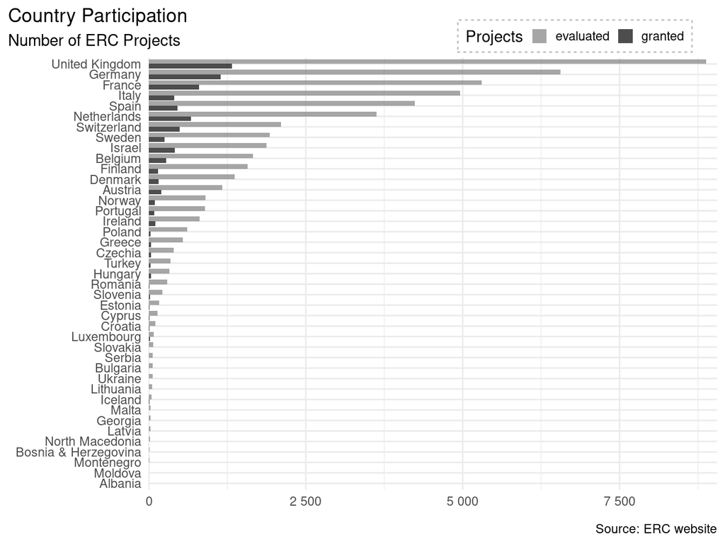

### LS

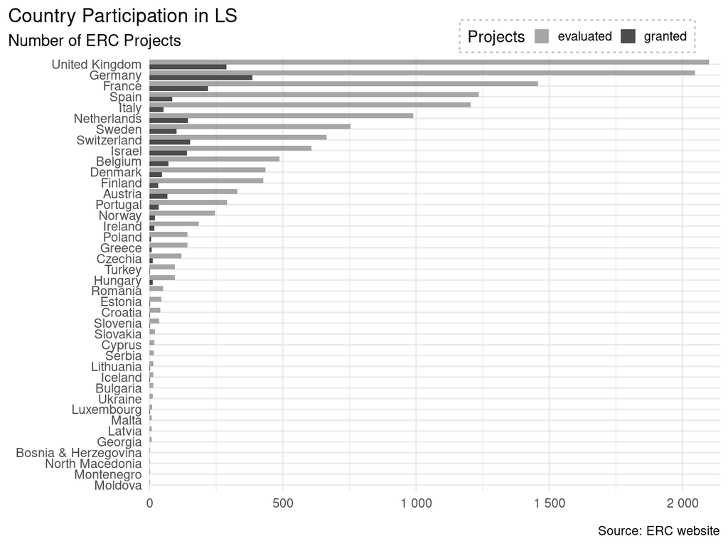

### PE

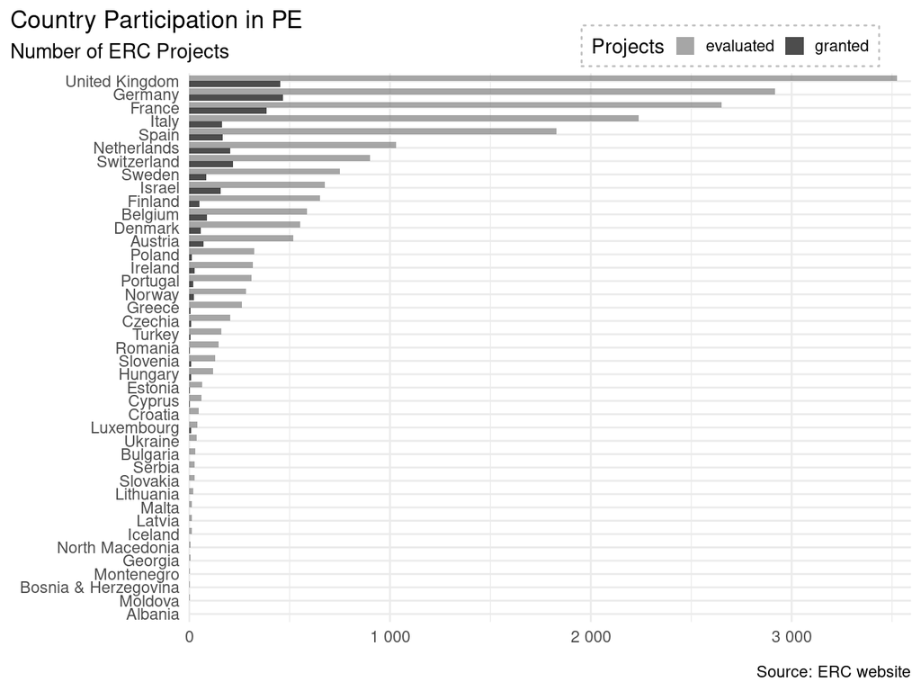

### SH

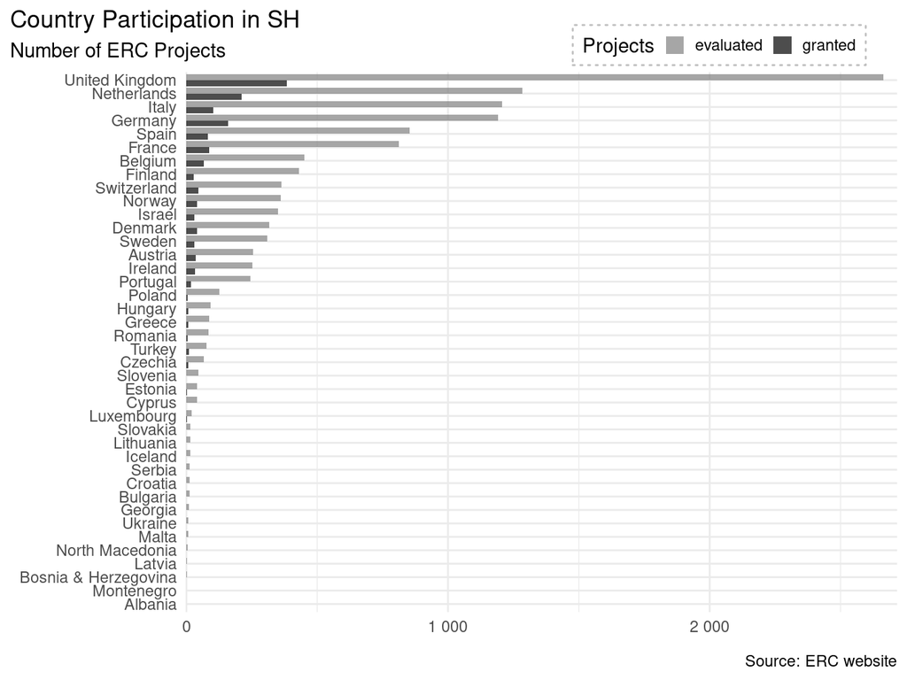

## Rankings of top participating countries

Comparison of the rankings by numbers of proposals and projects reveals consistent drops for Spain and Italy. By contrast, Germany, Israel, and Switzerland typically show better rankings for projects than for proposals.

### All

[figure not shown]

### LS

[figure not shown]

### PE

[figure not shown]

### SH

[figure not shown]

## Participation, GDP, and GERD

The observed inequality in country participation is largely mirrored in countries’ GDP and GERD levels. That applies for both EU28 and non-EU28 participants.

### Participation

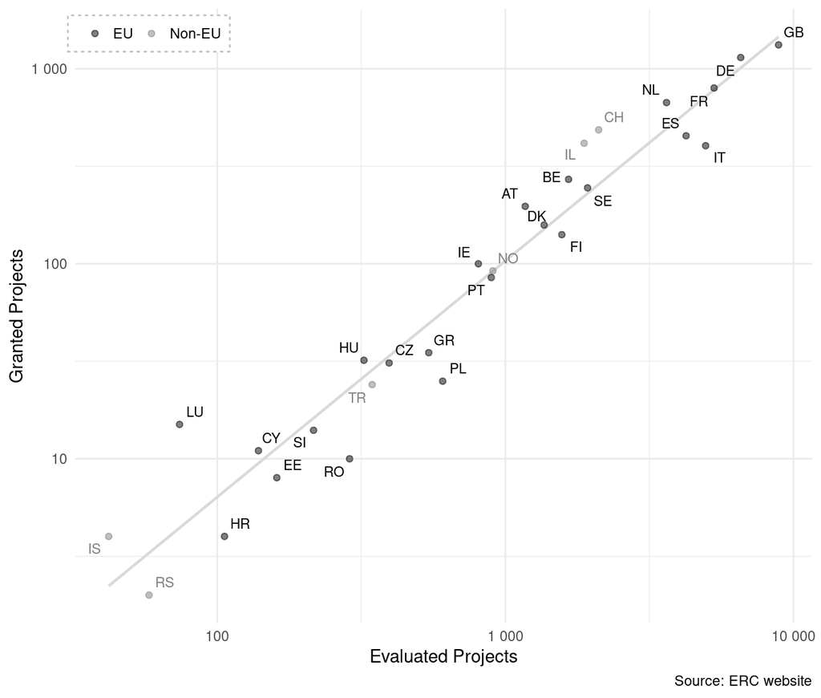

### GDP

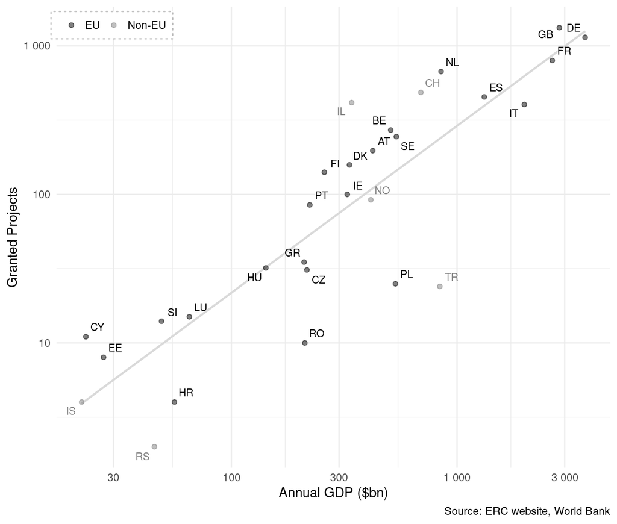

### GERD

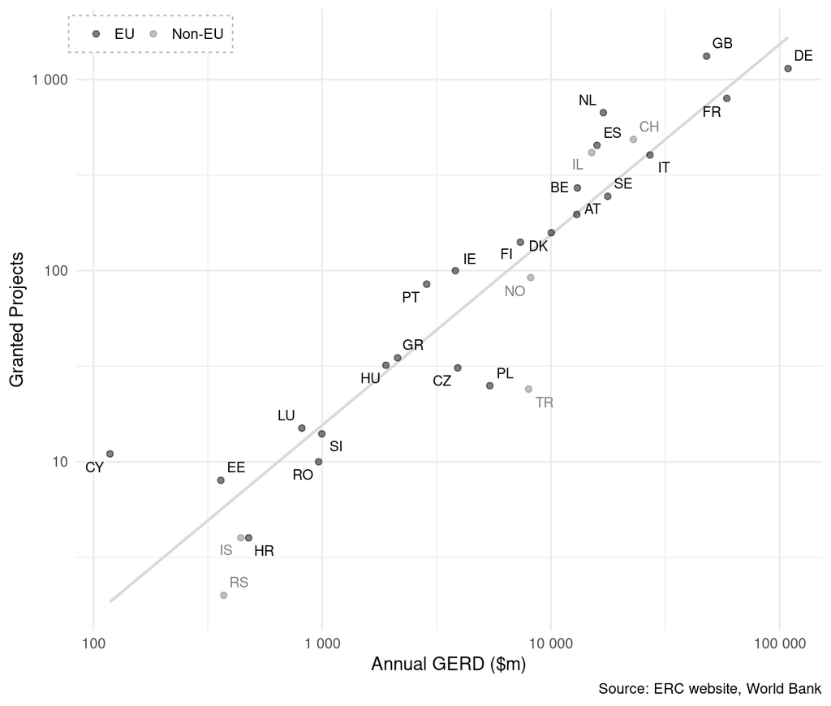

# Activity and success

The **activity index** of a country is the proportion of proposals of the country in a domain divided by the average proportion of proposals of other countries in that same domain.

The **success index** of a country is the success rate of the country in a domain divided by the average success rate of other countries in that same domain.

## Figures by domain

Comparison of the activity and success indexes of the 10 top participating countries among themselves provides a number of interesting individual observations:

- **LS**
  - Israel, Switzerland, and Germany have been outstandingly active and successful;
- **PE**
  - Switzerland and Israel have been extremely successful but only moderately active;
  - The Netherlands has been relatively successful but not so active;
- **SH**
  - both the UK and the Netherlands have been outstandingly active and successful.

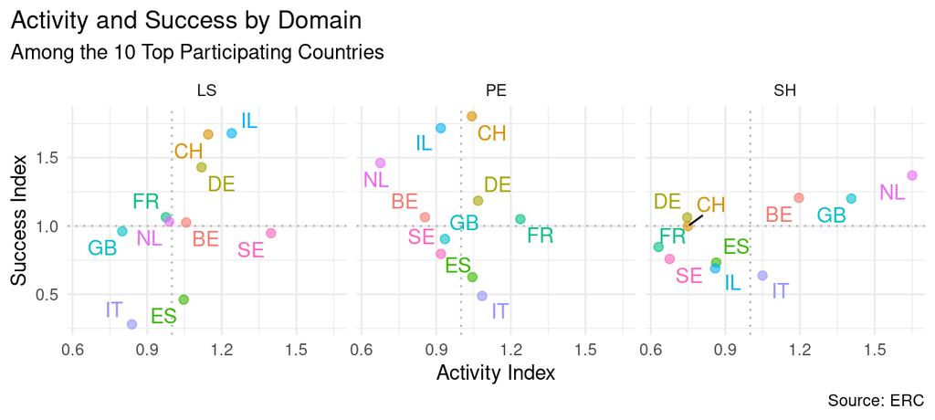

## Figures by panel

Among the 10 top participating countries:

- Israel stands out in LS2 (systems biology), PE1 (mathematics), and PE6 (computer science);
- Switzerland stands out in LS5 (neuroscience) and PE10 (earth science);
- The Netherlands stands out in PE7 (systems and communication engineering) and SH3 (environment, space, and population).

### LS

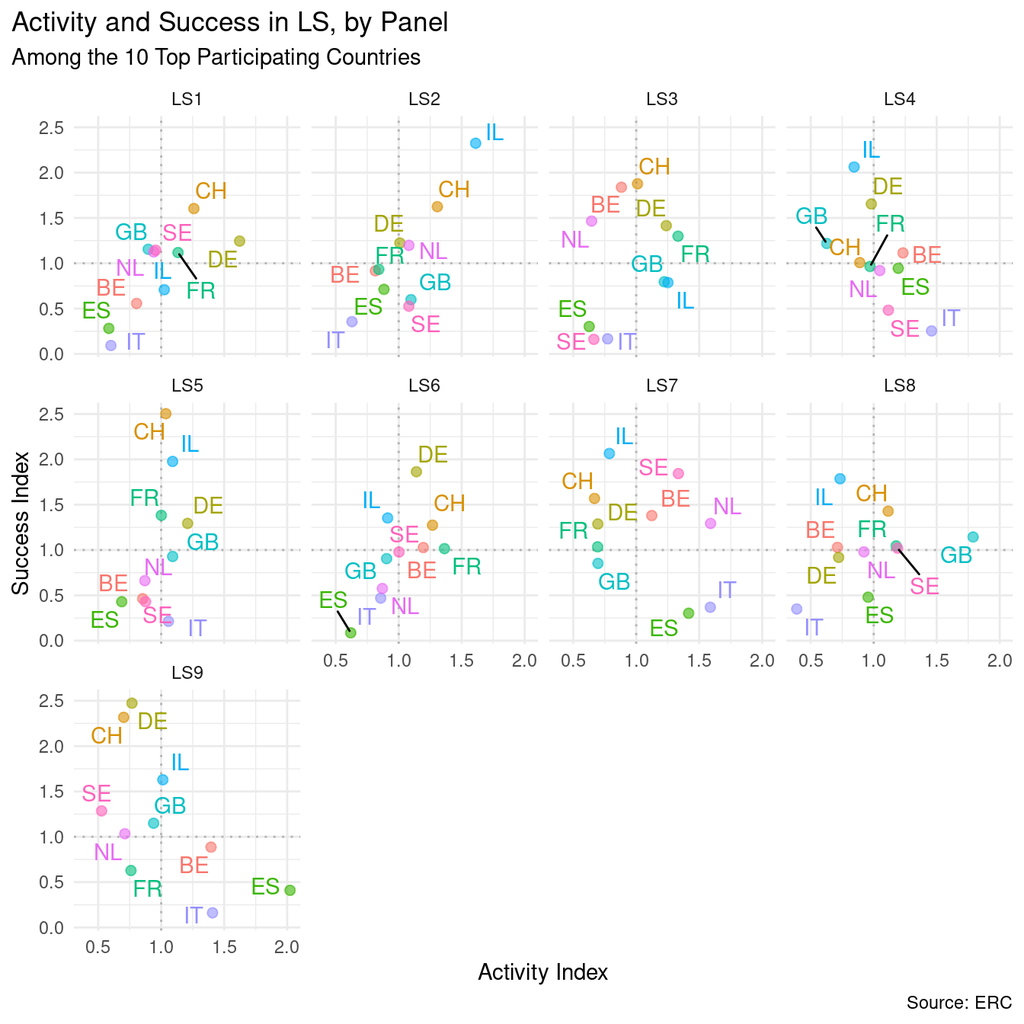

### PE

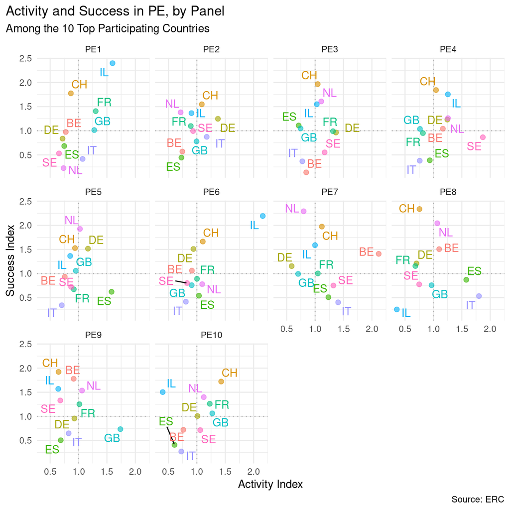

### SH

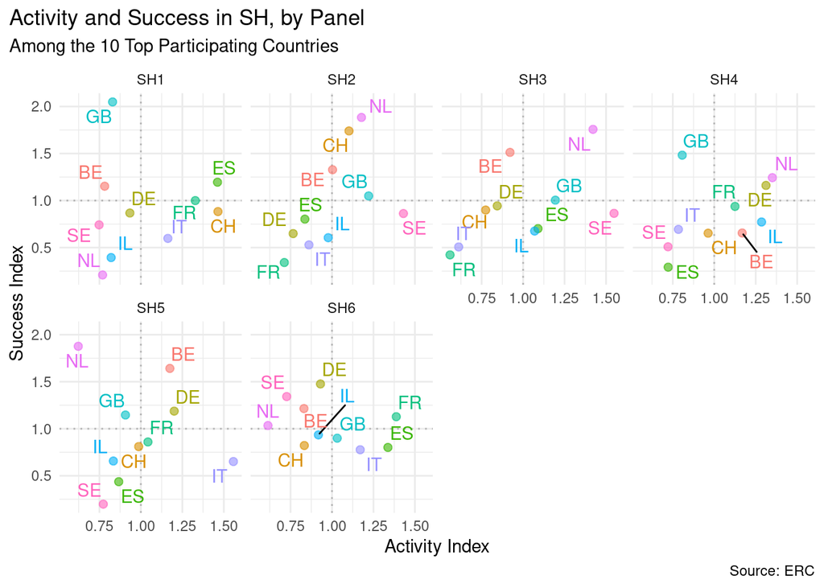

## Figures by domain for mid-range participating countries

- **LS**
  - Austria has been outstandingly successful but only moderately active;
- **PE**
  - Austria, again, has been outstandingly successful but only moderately active;
  - Norway has been relatively successful but not active;
  - Poland, Greece, Czechia, and Turkey show high activity but low success;
- **SH**
  - Ireland has been both active and relatively successful;
  - Austria has been relatively successful but not so active;
  - Norway has been extremely active, but only moderately successful.

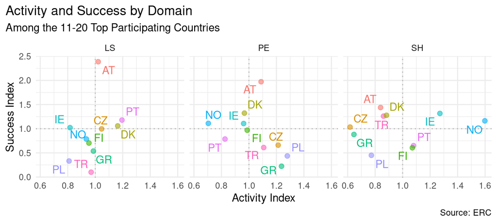

# See also

- [ERC funding activities 2007-2013: Key facts, patterns and trends](https://erc.europa.eu/sites/default/files/publication/files/ERC_funding_activities_2007_2013.pdf)